# Practica 2

Hector Najera

20/10/2022

```r
library(pacman)
p_load("psych", "lavaan", "haven")
```

# Introducción

Esta nota contiene dos tipos de análisis: **Exploratorio y confirmatorio**. El primero solamente se usa cuando el modelo de medición está pobre o limitadamente especificado.

# Datos

Para esta práctica vamos a trabajar con datos del índice de rezago social del CONEVAL 2015. Originalmente este índice municipal buscaba compensar por la falta de cifras de pobreza a nivel municipal. Hoy en día es parte del paquete de indicadores que le da el CONEVAL a la cámara de diputados para informar el PEF.

## Datos en `stata`.

```r
RS<-read_dta("RezagoSocial2015.dta")
```

# Análisis exploratorio

## Confiabilidad (Beta)

¿Se acuerdan qué intentaba detectar $\beta$?

```r
beta<-iclust(RS[,3:12], reverse=FALSE)
```

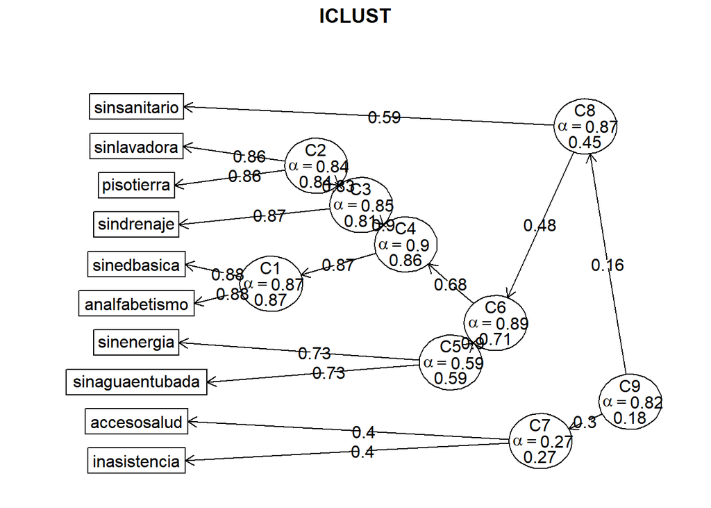

```r
beta$beta
```

```
## [1] 0.1765644
```

¿Qué significa Beta?

```r
beta
```

```
## ICLUST (Item Cluster Analysis)
## Call: iclust(r.mat = RS[, 3:12], reverse = FALSE)
##
## Purified Alpha:
## [1] 0.83
##
## G6* reliability:
## [1] 0.95
##
## Original Beta:
## [1] 0.18
##
## Cluster size:
## [1] 10
##
## Item by Cluster Structure matrix:
##                 [,1]
## analfabetismo    0.85
## inasistencia     0.33
## sinedbasica      0.78
## accesosalud     -0.11
## pisotierra       0.78
## sinsanitario     0.36
## sinaguaentubada  0.51
## sindrenaje       0.72
## sinenergia       0.65
## sinlavadora      0.80
##
## With eigenvalues of:
## [1] 4
##
## Purified scale intercorrelations
##  reliabilities on diagonal
##  correlations corrected for attenuation above diagonal:
##      [,1]
## [1,] 0.83
##
## Cluster fit =  0.81   Pattern fit =  0.98  RMSR =  0.08
```

# Confiabilidad Omega ($\omega$)

Recuerden que hay dos formas o estrategias de análisis de datos: Exploratoria y Confirmatoria. Hemos hablado que la confirmatoria es el ideal en medición pero en ocasiones no contamos con el conocimiento o teoría para lanzarnos a calcular un modelo confirmatorio. A continuación exploraremos ambos caminos paara los mismos datos. **Esto es para propósitos ilustrativos. Recuerden que no son formas complementarias sino sustitutas de análisis de datos**.

## Omega exploratorio

Para calcular $\omega$ a partir de un modelo factorial exploratorio utilizaremos el paquete `psych` y la función `omega()`. Esta función calcula $\omega$ a partir de un modelo factorial exploratorio asumiendo una estrutura de tres dimensiones (el default en las opciones es una estructura de tres dimensiones), en este caso asumiremos que no hay dimensiones puesto que partimos de que la medición es unidimensional. Para ello specificamos `nfactors=1`.

```r
omega<-omega(RS[,3:12], nfactors=1)
```

```
## Omega_h for 1 factor is not meaningful, just omega_t
```

```r
omega
```

```
## Omega
## Call: omegah(m = m, nfactors = nfactors, fm = fm, key = key, flip = flip,
##     digits = digits, title = title, sl = sl, labels = labels,
##     plot = plot, n.obs = n.obs, rotate = rotate, Phi = Phi, option = option,
##     covar = covar)
## Alpha:                 0.83
## G.6:                   0.86
## Omega Hierarchical:    0.85
## Omega H asymptotic:    1
## Omega Total            0.85
##
## Schmid Leiman Factor loadings greater than  0.2
##                    g  F1*   h2   u2 p2
## analfabetismo   0.86      0.73 0.27  1
## inasistencia    0.32      0.10 0.90  1
## sinedbasica     0.77      0.59 0.41  1
## accesosalud-              0.01 0.99  1
## pisotierra      0.80      0.64 0.36  1
## sinsanitario    0.32      0.10 0.90  1
## sinaguaentubada 0.51      0.26 0.74  1
## sindrenaje      0.72      0.52 0.48  1
## sinenergia      0.61      0.37 0.63  1
## sinlavadora     0.83      0.69 0.31  1
##
## With eigenvalues of:
##   g F1*
##   4   0
##
## general/max  7.250507e+16   max/min =   1
## mean percent general =  1    with sd =  0 and cv of  0
## Explained Common Variance of the general factor =  1
##
## The degrees of freedom are 35  and the fit is  0.77
## The number of observations was  2446  with Chi Square =  1872.45  with prob <  0
## The root mean square of the residuals is  0.08
## The df corrected root mean square of the residuals is  0.09
## RMSEA index =  0.147  and the 10 % confidence intervals are  0.141 0.152
## BIC =  1599.37
##
## Compare this with the adequacy of just a general factor and no group factors
## The degrees of freedom for just the general factor are 35  and the fit is  0.77
## The number of observations was  2446  with Chi Square =  1872.45  with prob <  0
## The root mean square of the residuals is  0.08
## The df corrected root mean square of the residuals is  0.09
##
## RMSEA index =  0.147  and the 10 % confidence intervals are  0.141 0.152
## BIC =  1599.37
##
## Measures of factor score adequacy
##                                                  g F1*
## Correlation of scores with factors            0.95   0
## Multiple R square of scores with factors      0.91   0
## Minimum correlation of factor score estimates 0.82  -1
##
##  Total, General and Subset omega for each subset
##                                                  g  F1*
## Omega total for total scores and subscales    0.85 0.85
## Omega general for total scores and subscales  0.85 0.85
## Omega group for total scores and subscales    0.00 0.00
```

Podemos graficar los resultados con:

```
## Use omega.diagram to see the  hierarchical structure
```

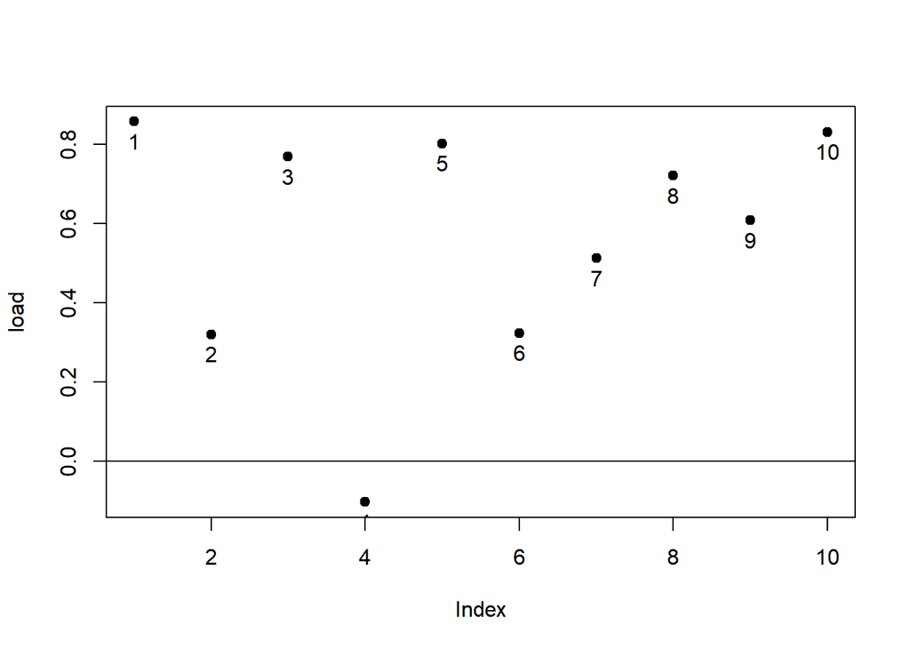

```r
plot(omega)
```

# Qué pasa si me quedo con las mejores -preguntas-

```r
omegaAlter<-omega(RS[,c(3,5,7,10,12)], nfactors=1)
```

```
## Omega_h for 1 factor is not meaningful, just omega_t
```

```r
omegaAlter
```

```
## Omega
## Call: omegah(m = m, nfactors = nfactors, fm = fm, key = key, flip = flip,
##     digits = digits, title = title, sl = sl, labels = labels,
##     plot = plot, n.obs = n.obs, rotate = rotate, Phi = Phi, option = option,
##     covar = covar)
## Alpha:                 0.9
## G.6:                   0.89
## Omega Hierarchical:    0.9
## Omega H asymptotic:    1
## Omega Total            0.9
##
## Schmid Leiman Factor loadings greater than  0.2
##                  g  F1*   h2   u2 p2
## analfabetismo 0.87      0.76 0.24  1
## sinedbasica   0.77      0.60 0.40  1
## pisotierra    0.80      0.63 0.37  1
## sindrenaje    0.71      0.50 0.50  1
## sinlavadora   0.87      0.76 0.24  1
##
## With eigenvalues of:
##   g F1*
## 3.2 0.0
##
## general/max  Inf   max/min =   NaN
## mean percent general =  1    with sd =  0 and cv of  0
## Explained Common Variance of the general factor =  1
##
## The degrees of freedom are 5  and the fit is  0.19
## The number of observations was  2446  with Chi Square =  474.41  with prob <  2.7e-100
## The root mean square of the residuals is  0.05
## The df corrected root mean square of the residuals is  0.07
## RMSEA index =  0.196  and the 10 % confidence intervals are  0.181 0.211
## BIC =  435.4
##
## Compare this with the adequacy of just a general factor and no group factors
## The degrees of freedom for just the general factor are 5  and the fit is  0.19
## The number of observations was  2446  with Chi Square =  474.41  with prob <  2.7e-100
## The root mean square of the residuals is  0.05
## The df corrected root mean square of the residuals is  0.07
##
## RMSEA index =  0.196  and the 10 % confidence intervals are  0.181 0.211
## BIC =  435.4
##
## Measures of factor score adequacy
##                                                  g F1*
## Correlation of scores with factors            0.96   0
## Multiple R square of scores with factors      0.91   0
## Minimum correlation of factor score estimates 0.83  -1
##
##  Total, General and Subset omega for each subset
##                                                 g F1*
## Omega total for total scores and subscales    0.9 0.9
## Omega general for total scores and subscales  0.9 0.9
## Omega group for total scores and subscales    0.0 0.0
```

Comparamos las subescalas

```r
results<-c(omega$omega.tot,omegaAlter$omega.tot)
results
```

```
## [1] 0.8512037 0.9015635
```

Correlacion observada con el factor

```r
results2<-c(omega$stats$fit.off,omegaAlter$stats$fit.off)
results2
```

```
## [1] 0.9635615 0.9943169
```

Pesos: En caso de que quisieran producir una medición con pesos diferenciales. ¿Pero para qué? ¿Cuál es la correlación con el factor?

```r
pesos<-omegaAlter$stats$weights
pesos
```

```
##                       g F1*
## analfabetismo 0.3228934   0
## sinedbasica   0.1462830   0
## pisotierra    0.1991258   0
## sindrenaje    0.1285449   0
## sinlavadora   0.3098951   0
```

```r
sum(pesos)
```

```
## [1] 1.106742
```

## Exploración de más dimensiones

Si ustedes quisieran explorar (**incorrectamente en este caso** ) con una solución para tres factores:

```r
omega3<-omega(RS[,3:12], nfactors=3)
```

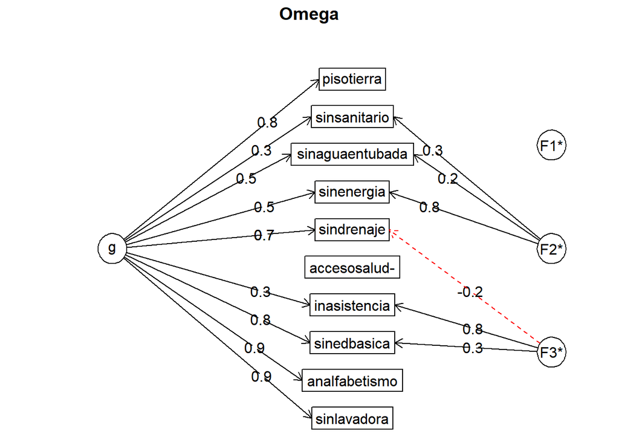

```r
omega3
```

```
## Omega
## Call: omegah(m = m, nfactors = nfactors, fm = fm, key = key, flip = flip,
##     digits = digits, title = title, sl = sl, labels = labels,
##     plot = plot, n.obs = n.obs, rotate = rotate, Phi = Phi, option = option,
##     covar = covar)
## Alpha:                 0.83
## G.6:                   0.86
## Omega Hierarchical:    0.8
## Omega H asymptotic:    0.9
## Omega Total            0.89
##
## Schmid Leiman Factor loadings greater than  0.2
##                     g   F1*   F2*   F3*   h2   u2   p2
## analfabetismo    0.87                   0.78 0.22 0.98
## inasistencia     0.29              0.79 0.71 0.29 0.12
## sinedbasica      0.79              0.27 0.70 0.30 0.89
## accesosalud-                      -0.20 0.06 0.94 0.17
## pisotierra       0.79                   0.64 0.36 0.98
## sinsanitario     0.26        0.30       0.16 0.84 0.41
## sinaguaentubada  0.47        0.23       0.28 0.72 0.81
## sindrenaje       0.72             -0.20 0.59 0.41 0.88
## sinenergia       0.52        0.77       0.86 0.14 0.31
## sinlavadora      0.87                   0.76 0.24 0.99
##
## With eigenvalues of:
##    g  F1*  F2*  F3*
## 3.93 0.00 0.79 0.82
##
## general/max  4.78   max/min =   Inf
## mean percent general =  0.65    with sd =  0.36 and cv of  0.55
## Explained Common Variance of the general factor =  0.71
##
## The degrees of freedom are 18  and the fit is  0.22
## The number of observations was  2446  with Chi Square =  546.29  with prob <  1.9e-104
## The root mean square of the residuals is  0.03
## The df corrected root mean square of the residuals is  0.05
## RMSEA index =  0.11  and the 10 % confidence intervals are  0.102 0.118
## BIC =  405.85
##
## Compare this with the adequacy of just a general factor and no group factors
## The degrees of freedom for just the general factor are 35  and the fit is  0.77
## The number of observations was  2446  with Chi Square =  1867.92  with prob <  0
## The root mean square of the residuals is  0.08
## The df corrected root mean square of the residuals is  0.1
##
## RMSEA index =  0.146  and the 10 % confidence intervals are  0.141 0.152
## BIC =  1594.84
##
## Measures of factor score adequacy
##                                                  g F1*  F2*  F3*
## Correlation of scores with factors            0.96   0 0.89 0.85
## Multiple R square of scores with factors      0.92   0 0.79 0.73
## Minimum correlation of factor score estimates 0.84  -1 0.59 0.46
##
##  Total, General and Subset omega for each subset
##                                                  g F1*  F2*  F3*
## Omega total for total scores and subscales    0.89  NA 0.75 0.84
## Omega general for total scores and subscales  0.80  NA 0.51 0.81
## Omega group for total scores and subscales    0.06  NA 0.24 0.03
```

Para obtener la varianza total pueden usar `omega3$schmid$sl`.

- g: Carga factorial del factor general
- F1-F3: Carga factorial del factor de segundo orden
- h2: La varianza total que se explica por los factores. $\lambda_g^2 + \lambda_f^2$
- u2: El error total del indicador
- p2: EL % de la varianza comun que es del factor general. Fuerza del factor general. .97>.12

```r
omega3$schmid$sl
```

```
##                         g F1*         F2*         F3*        h2        u2
## analfabetismo   0.8728691   0 -0.02955679  0.12665448 0.7806318 0.2193682
## inasistencia    0.2890921   0  0.07631984  0.79179605 0.7138612 0.2861388
## sinedbasica     0.7855782   0 -0.04756940  0.26879482 0.6965005 0.3034995
## accesosalud-    0.1007392   0  0.10001257 -0.19647352 0.0595030 0.9404970
## pisotierra      0.7917166   0  0.11376099 -0.05375976 0.6424011 0.3575989
## sinsanitario    0.2588921   0  0.29560737  0.10108968 0.1632506 0.8367494
## sinaguaentubada 0.4742054   0  0.22518675 -0.03889595 0.2781237 0.7218763
## sindrenaje      0.7202409   0  0.17993312 -0.20101245 0.5911074 0.4088926
## sinenergia      0.5180459   0  0.76582365  0.04976637 0.8553314 0.1446686
## sinlavadora     0.8677541   0 -0.01453691 -0.10349705 0.7601448 0.2398552
##                        p2
## analfabetismo   0.9760049
## inasistencia    0.1170735
## sinedbasica     0.8860482
## accesosalud-    0.1705526
## pisotierra      0.9757381
## sinsanitario    0.4105659
## sinaguaentubada 0.8085280
## sindrenaje      0.8775849
## sinenergia      0.3137632
## sinlavadora     0.9905972
```

# Análsis confirmatorio con `lavaan`

En la sección previa trabajos bajo el supuesto de que el modelo de medición estaba pobremente definido puesto que no existía una estructura clara de los datos. En realidad, el CONEVAL “parece” suponer que el rezago social es una medida unidimensional.

Para evitar poner todos los nombres vamos a usar la función `paste0`. De otra manera puedes poner los nombres manualmente.

```r
n<-paste0(names(RS[,3:12]), collapse = "+")
n<-paste0("h=~",n,sep="")

n
```

```
## [1] "h=~analfabetismo+inasistencia+sinedbasica+accesosalud+pisotierra+sinsanitario+sinaguaentubada+sindrenaje+sinenergia+sinlavadora"
```

```r
UD_model <- n


fit1 <- sem(UD_model, data = RS[,3:12],
           std.lv=TRUE)
```

Ajuste global

```r
summary(fit1, fit.measure=TRUE, ci=TRUE, nd=3)
```

```
## lavaan 0.6-9 ended normally after 34 iterations
##
##   Estimator                                         ML
##   Optimization method                           NLMINB
##   Number of model parameters                        20
##
##   Number of observations                          2446
##
## Model Test User Model:
##
##   Test statistic                              1844.248
##   Degrees of freedom                                35
##   P-value (Chi-square)                           0.000
##
## Model Test Baseline Model:
##
##   Test statistic                             11030.542
##   Degrees of freedom                                45
##   P-value                                        0.000
##
## User Model versus Baseline Model:
##
##   Comparative Fit Index (CFI)                    0.835
##   Tucker-Lewis Index (TLI)                       0.788
##
## Loglikelihood and Information Criteria:
##
##   Loglikelihood user model (H0)             -83720.591
##   Loglikelihood unrestricted model (H1)     -82798.467
##
##   Akaike (AIC)                              167481.181
##   Bayesian (BIC)                            167597.226
##   Sample-size adjusted Bayesian (BIC)       167533.681
##
## Root Mean Square Error of Approximation:
##
##   RMSEA                                          0.145
##   90 Percent confidence interval - lower         0.140
##   90 Percent confidence interval - upper         0.151
##   P-value RMSEA <= 0.05                          0.000
```

[output cut: 23 more lines]

```
##     sinlavadora      21.254    0.413   51.407    0.000   20.444   22.065
##
## Variances:
##                    Estimate  Std.Err  z-value  P(>|z|) ci.lower ci.upper
##    .analfabetismo    17.825    0.711   25.057    0.000   16.431   19.219
##    .inasistencia      6.063    0.175   34.604    0.000    5.719    6.406
##    .sinedbasica      81.333    2.724   29.853    0.000   75.994   86.673
##    .accesosalud      52.898    1.514   34.940    0.000   49.930   55.865
##    .pisotierra       29.267    0.996   29.381    0.000   27.315   31.219
##    .sinsanitario     47.015    1.356   34.664    0.000   44.356   49.673
##    .sinaguaentubad   97.143    2.861   33.951    0.000   91.535  102.751
##    .sindrenaje      249.976    7.880   31.723    0.000  234.532  265.421
##    .sinenergia        8.030    0.240   33.477    0.000    7.560    8.500
##    .sinlavadora     168.034    6.401   26.249    0.000  155.487  180.580
##     h                 1.000                               1.000    1.000
```

Confiabilidad

```r
library(semTools)
reliability(fit1)
```

```
##                h
## alpha  0.7912416
## omega  0.8753284
## omega2 0.8753284
## omega3 0.8798662
## avevar 0.5646914
```

## Tiro indicadores

```r
n<-paste0(names(RS[,c(3,5,7,10,12)]), collapse = "+")
n<-paste0("h=~",n,sep="")

n
```

```
## [1] "h=~analfabetismo+sinedbasica+pisotierra+sindrenaje+sinlavadora"
```

```r
UD_model <- n


fit2 <- sem(UD_model, data = RS[,c(3,5,7,10,12)],
           std.lv=TRUE)
```

Ajuste global

```r
summary(fit2, fit.measure=TRUE, ci=TRUE, nd=3)
```

```
## lavaan 0.6-9 ended normally after 16 iterations
##
##   Estimator                                         ML
##   Optimization method                           NLMINB
##   Number of model parameters                        10
##
##   Number of observations                          2446
##
## Model Test User Model:
##
##   Test statistic                               471.161
##   Degrees of freedom                                 5
##   P-value (Chi-square)                           0.000
##
## Model Test Baseline Model:
##
##   Test statistic                              7794.219
##   Degrees of freedom                                10
##   P-value                                        0.000
##
## User Model versus Baseline Model:
##
##   Comparative Fit Index (CFI)                    0.940
##   Tucker-Lewis Index (TLI)                       0.880
##
## Loglikelihood and Information Criteria:
##
##   Loglikelihood user model (H0)             -46310.605
##   Loglikelihood unrestricted model (H1)     -46075.025
##
##   Akaike (AIC)                               92641.211
##   Bayesian (BIC)                             92699.233
##   Sample-size adjusted Bayesian (BIC)        92667.460
##
## Root Mean Square Error of Approximation:
##
##   RMSEA                                          0.195
##   90 Percent confidence interval - lower         0.181
##   90 Percent confidence interval - upper         0.210
##   P-value RMSEA <= 0.05                          0.000
```

[output cut: 13 more lines]

```
##   h =~
##     analfabetismo     7.432    0.140   53.121    0.000    7.158    7.706
##     sinedbasica      11.421    0.253   45.201    0.000   10.925   11.916
##     pisotierra        7.050    0.156   45.312    0.000    6.745    7.355
##     sindrenaje       15.683    0.410   38.256    0.000   14.880   16.487
##     sinlavadora      21.580    0.411   52.449    0.000   20.773   22.386
##
## Variances:
##                    Estimate  Std.Err  z-value  P(>|z|) ci.lower ci.upper
##    .analfabetismo    17.112    0.724   23.638    0.000   15.693   18.531
##    .sinedbasica      80.584    2.742   29.391    0.000   75.211   85.958
##    .pisotierra       30.439    1.037   29.340    0.000   28.406   32.473
##    .sindrenaje      258.911    8.158   31.738    0.000  242.923  274.900
##    .sinlavadora     154.099    6.330   24.344    0.000  141.692  166.505
##     h                 1.000                               1.000    1.000
```

Confiabilidad

```r
library(semTools)
reliability(fit1)
```

```
##                h
## alpha  0.7912416
## omega  0.8753284
## omega2 0.8753284
## omega3 0.8798662
## avevar 0.5646914
```

Tal vez me gustaría graficar mi modelo (Si van a publicar algo es mejor graficar)

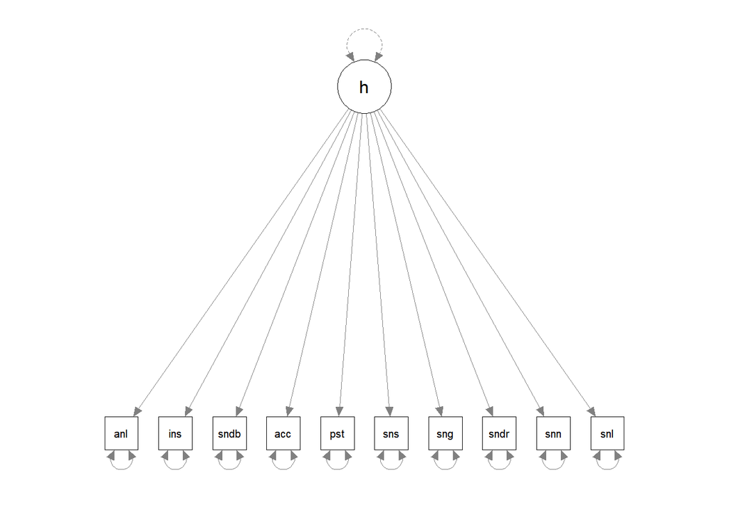

```r
library(semPlot)
semPaths(fit1)
```

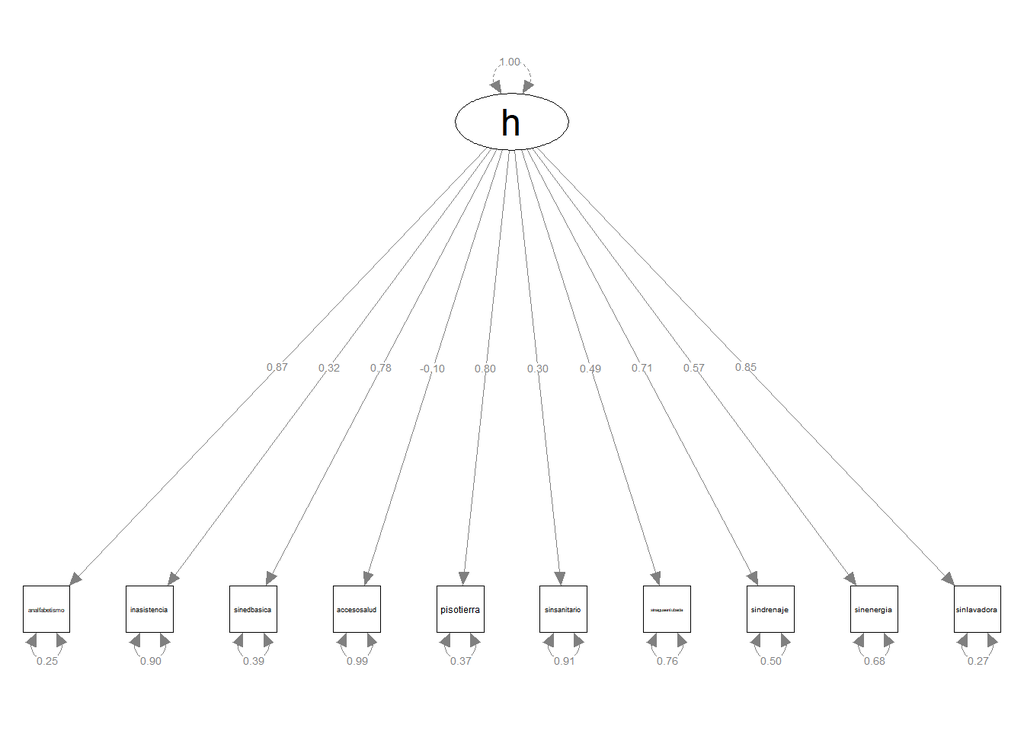

```r
diag<-semPaths(fit1, "model", "std",
         curve = 0.8, nCharNodes = 0,
        sizeLat = 12, sizeLat2 = 6, title = TRUE,
        mar = c(5, 1, 5, 1), curvePivot = FALSE,
        edge.label.cex = 0.5)
```

## Tal vez lo mejor es revisar los índices de modificación del primer modelo

Parece que tendría que correlacionar los errores de algunas variables para mejorar el ajuste. ¿Qué dice el modelo teórico?

```r
modindices(fit1, sort = TRUE, maximum.number = 5)
```

```
##              lhs op         rhs      mi     epc sepc.lv sepc.all sepc.nox
## 23 analfabetismo ~~ sinedbasica 414.428  22.476  22.476    0.590    0.590
## 31  inasistencia ~~ sinedbasica 303.477   8.524   8.524    0.384    0.384
## 59  sinsanitario ~~  sinenergia 172.340   5.298   5.298    0.273    0.273
## 36  inasistencia ~~  sindrenaje 149.393 -10.168 -10.168   -0.261   -0.261
## 38  inasistencia ~~ sinlavadora 142.044  -8.936  -8.936   -0.280   -0.280
```

Modelo 1 modificado (ejemplo)

```r
UD_modelmod<-"h=~analfabetismo+sinedbasica+pisotierra+sindrenaje+sinlavadora
              analfabetismo ~~  sinedbasica
            "
fit1.a <- sem(UD_modelmod, data = RS[,c(3:12)],
           std.lv=TRUE)
```

Reviso ajuste global

```r
summary(fit1.a, fit.measure=TRUE, ci=TRUE, nd=3)
```

```
## lavaan 0.6-9 ended normally after 30 iterations
##
##   Estimator                                         ML
##   Optimization method                           NLMINB
##   Number of model parameters                        11
##
##   Number of observations                          2446
##
## Model Test User Model:
##
##   Test statistic                                79.739
##   Degrees of freedom                                 4
##   P-value (Chi-square)                           0.000
##
## Model Test Baseline Model:
##
##   Test statistic                              7794.219
##   Degrees of freedom                                10
##   P-value                                        0.000
##
## User Model versus Baseline Model:
##
##   Comparative Fit Index (CFI)                    0.990
##   Tucker-Lewis Index (TLI)                       0.976
##
## Loglikelihood and Information Criteria:
##
##   Loglikelihood user model (H0)             -46114.894
##   Loglikelihood unrestricted model (H1)     -46075.025
##
##   Akaike (AIC)                               92251.789
##   Bayesian (BIC)                             92315.613
##   Sample-size adjusted Bayesian (BIC)        92280.664
##
## Root Mean Square Error of Approximation:
##
##   RMSEA                                          0.088
##   90 Percent confidence interval - lower         0.072
##   90 Percent confidence interval - upper         0.105
##   P-value RMSEA <= 0.05                          0.000
```

[output cut: 18 more lines]

```
##     sinlavadora      22.342    0.409   54.692    0.000   21.542   23.143
##
## Covariances:
##                    Estimate  Std.Err  z-value  P(>|z|) ci.lower ci.upper
##  .analfabetismo ~~
##    .sinedbasica      23.355    1.433   16.293    0.000   20.546   26.164
##
## Variances:
##                    Estimate  Std.Err  z-value  P(>|z|) ci.lower ci.upper
##    .analfabetismo    23.874    0.901   26.485    0.000   22.107   25.641
##    .sinedbasica     105.075    3.459   30.378    0.000   98.296  111.855
##    .pisotierra       26.940    1.001   26.911    0.000   24.977   28.902
##    .sindrenaje      248.118    8.022   30.931    0.000  232.396  263.840
##    .sinlavadora     120.595    6.551   18.409    0.000  107.756  133.435
##     h                 1.000                               1.000    1.000
```

## Comparmo mis modelos

Acá tenemos que usar otro paquete llamado `semTable`. Los modelos se ordenan del mejor al peor ajuste.

```r
library(semTable)
models <- list(fit1, fit1.a, fit2)
## Note, nesting is not specified, so built-in nesting detection applies
compareLavaan(models)
```

```
##           chisq df pvalue rmsea   cfi   tli  srmr       aic       bic dchi ddf
## Model2   79.739  4      0 0.088 0.990 0.976 0.016  92251.79  92315.61    -   -
## Model3  471.161  5      0 0.195 0.940 0.880 0.040  92641.21  92699.23    -   -
## Model1 1844.248 35      0 0.145 0.835 0.788 0.071 167481.18 167597.23    -   -
##        npval
## Model2     -
## Model3     -
## Model1     -
```